# Fruitflies Example

Alexandra Chronopoulou

Lecture 15 Example

## Longevity of fruitflies depending on sexual activity and thorax length

- One group was kept solitary (isolated)
- One group was kept with a virgin female each day (low)
- One group was kept with 8 virgin females per day (high)
- One group was kept with one pregnant female per day (one)
- One group was kept with eight pregnant female per day (many)

Pregnant fruitflies will not mate. The thorax length of each male was measured as this was known to affect longevity. One observation in the many group has been lost. So the total sample size is 124.

```r
library(faraway)
data(fruitfly)
head(fruitfly)
```

```
##   thorax longevity activity
## 1   0.68        37     many
## 2   0.68        49     many
## 3   0.72        46     many
## 4   0.72        63     many
## 5   0.76        39     many
## 6   0.76        46     many
```

```r
fruitfly$a
```

```
##   [1] many     many     many     many     many     many     many     many
##   [9] many     many     many     many     many     many     many     many
##  [17] many     many     many     many     many     many     many     many
##  [25] isolated isolated isolated isolated isolated isolated isolated isolated
##  [33] isolated isolated isolated isolated isolated isolated isolated isolated
##  [41] isolated isolated isolated isolated isolated isolated isolated isolated
##  [49] isolated one      one      one      one      one      one      one
##  [57] one      one      one      one      one      one      one      one
##  [65] one      one      one      one      one      one      one      one
##  [73] one      one      low      low      low      low      low      low
##  [81] low      low      low      low      low      low      low      low
##  [89] low      low      low      low      low      low      low      low
##  [97] low      low      low      high     high     high     high     high
## [105] high     high     high     high     high     high     high     high
## [113] high     high     high     high     high     high     high     high
## [121] high     high     high     high
## Levels: isolated one low many high
```

```r
dim(fruitfly)
```

```
## [1] 124   3
```

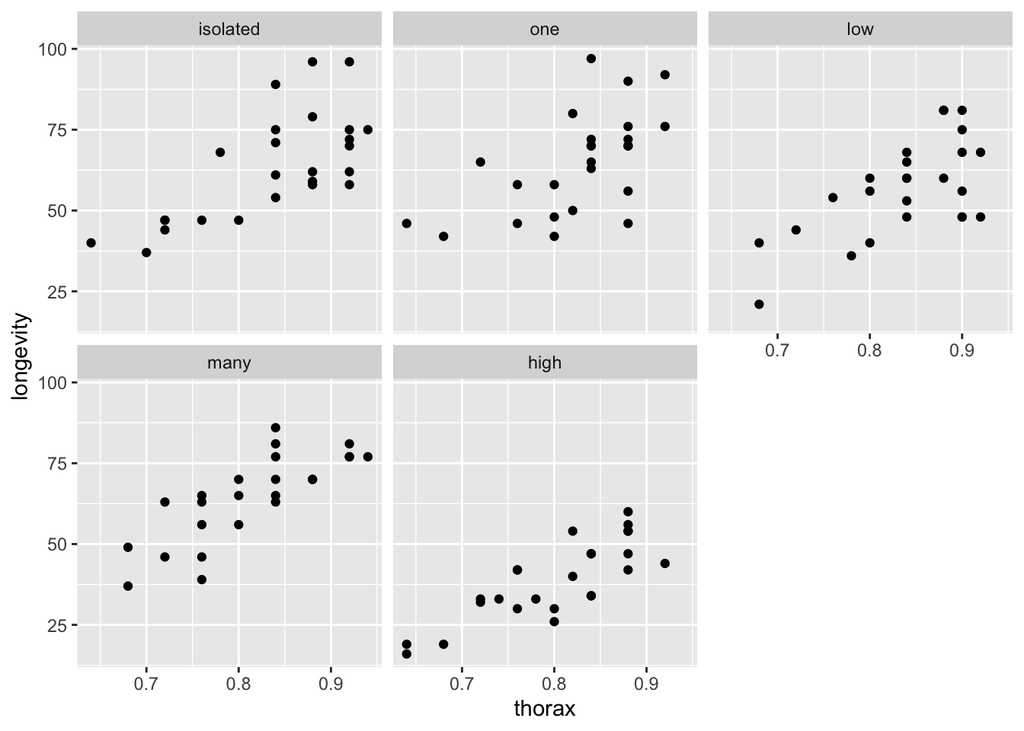

```r
library(ggplot2)
ggplot(aes(x = thorax, y=longevity), data=fruitfly) + geom_point() +
  facet_wrap(~activity)
```

Fit the most general model, i.e., the model including the interaction. Then use the two sequential ANOVA tables to select an approrpiate model for the data.

```r
lmod= lm(longevity ~ thorax * activity, fruitfly)
# summary(lmod)
anova(lmod)
```

```
## Analysis of Variance Table
##
## Response: longevity
##                  Df  Sum Sq Mean Sq F value    Pr(>F)
## thorax            1 15003.3 15003.3 130.733 < 2.2e-16 ***
## activity          4  9634.6  2408.6  20.988 5.503e-13 ***
## thorax:activity   4    24.3     6.1   0.053    0.9947
## Residuals       114 13083.0   114.8
## ---
## Signif. codes:  0 '***' 0.001 '**' 0.01 '*' 0.05 '.' 0.1 ' ' 1
```

```r
anova(lm(longevity ~ activity * thorax, fruitfly))
```

```
## Analysis of Variance Table
##
## Response: longevity
##                  Df  Sum Sq Mean Sq F value  Pr(>F)
## activity          4 12269.5  3067.4  26.728 1.2e-15 ***
## thorax            1 12368.4 12368.4 107.774 < 2e-16 ***
## activity:thorax   4    24.3     6.1   0.053  0.9947
## Residuals       114 13083.0   114.8
## ---
## Signif. codes:  0 '***' 0.001 '**' 0.01 '*' 0.05 '.' 0.1 ' ' 1
```

The p-value from the F-test for the interaction term should be the same in both tables. Apparently, the interaction term is not significant. Do we need both thorax and activity, or just one of them, or neither? Thorax makes a significant contribution to the response variable. It does not matter whether the other variable `activity` is included or not; same thing for `activity`. So we should pick the additive model.

```r
lmod.add = lm(longevity ~ thorax + activity, fruitfly)
summary(lmod.add)
```

```
##
## Call:
## lm(formula = longevity ~ thorax + activity, data = fruitfly)
##
## Residuals:
##     Min      1Q  Median      3Q     Max
## -26.108  -7.014  -1.101   6.234  30.265
##
## Coefficients:
##              Estimate Std. Error t value Pr(>|t|)
## (Intercept)   -48.749     10.850  -4.493 1.65e-05 ***
## thorax        134.341     12.731  10.552  < 2e-16 ***
## activityone     2.637      2.984   0.884   0.3786
## activitylow    -7.015      2.981  -2.353   0.0203 *
## activitymany    4.139      3.027   1.367   0.1741
## activityhigh  -20.004      3.016  -6.632 1.05e-09 ***
## ---
## Signif. codes:  0 '***' 0.001 '**' 0.01 '*' 0.05 '.' 0.1 ' ' 1
##
## Residual standard error: 10.54 on 118 degrees of freedom
## Multiple R-squared:  0.6527, Adjusted R-squared:  0.638
## F-statistic: 44.36 on 5 and 118 DF,  p-value: < 2.2e-16
```

Back to the sequential ANOVA tables. As being mentioned in the notes, some of the F-tests in the sequential ANOVA table are computed slightly different from the F-test we learned before for comparing two nested models. But they are not wrong, but just constructed slightly differently, and they are theoretically sound procedures.

Suppose we want to compare the following two models

**Null: longevity ~ thorax**

**Alternative: longevity ~ thorax + activity**

We can use the F-test formula for comparing two nested models which will give us an F-stat, or we can grab the F-stat from the **sequential ANOVA table**. The two numbers are different since the denominators are different: in one, we use the sigma-hat from the alternative model **longevity ~ thorax + activity**, but in the other, we use the sigma-hat from the bigger model **longevity ~ thorax + activity + thorax:activity**.

```r
anova(lm(longevity ~ thorax, fruitfly), lmod.add)
```

```
## Analysis of Variance Table
##
## Model 1: longevity ~ thorax
## Model 2: longevity ~ thorax + activity
##   Res.Df   RSS Df Sum of Sq      F    Pr(>F)
## 1    122 22742
## 2    118 13107  4    9634.6 21.684 1.974e-13 ***
## ---
## Signif. codes:  0 '***' 0.001 '**' 0.01 '*' 0.05 '.' 0.1 ' ' 1
```

```r
9634.6/4/(13107/118)  # follows F(4, 118) dist under the null
```

```
## [1] 21.68465
```

```r
anova(lmod)
```

```
## Analysis of Variance Table
##
## Response: longevity
##                  Df  Sum Sq Mean Sq F value    Pr(>F)
## thorax            1 15003.3 15003.3 130.733 < 2.2e-16 ***
## activity          4  9634.6  2408.6  20.988 5.503e-13 ***
## thorax:activity   4    24.3     6.1   0.053    0.9947
## Residuals       114 13083.0   114.8
## ---
## Signif. codes:  0 '***' 0.001 '**' 0.01 '*' 0.05 '.' 0.1 ' ' 1
```

```r
9634.6/4/(13083/114)  # follows F(4, 114) dist under the null
```

```
## [1] 20.98801
```